# Bi-directional voltage source converter

A single-phase bi-directional voltage source converter is connected to an AC voltage source through an inductor $L = 10\,$mH as given below. All the switches are ideal and are operated using the sinusoidal pulse width modulation (SPWM) technique. The dc link voltage is $500\,$V. The AC source voltage is $230\,\angle{0}\,$V. The PWM carrier signal is a triangle wave between $-1$ and $1$ with a frequency of $10\,$kHz, and the modulating signal is $v_{ref}(t) = M\,\sin\,(\omega \,t + \phi)$. The inverter injects 5 kW of power at unity power factor to the AC source. Determine $M$ and $\phi$ (in degrees). Draw the phasor diagram showing the relationship between inverter voltage, grid voltage, and the voltage across the inductor. (Follow the convention that $\sin\,\omega\,t$ corresponds to the phasor $1\angle{0}$.)

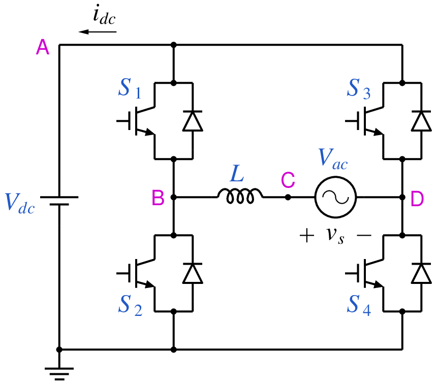

```python
from IPython.display import Image
Image(filename =r'VSC_bi_5_fig_1.png', width=300)
```

```python
# run this cell to view the circuit file.
%pycat VSC_bi_5_orig.in
```

We now replace the strings such as \$Vdc, \$L, with the values of our choice by running the python script given below. It takes an existing circuit file `VSC_bi_5_orig.in` and produces a new circuit file `VSC_bi_5.in`, after replacing \$Vdc, \$L, etc. with values of our choice.

```python
import gseim_calc as calc
import numpy as np

s_Vdc = "500"
s_L = "10e-3"
s_f_carrier = "10e3"
s_M = "0.6" # to be changed by user
s_phi = "14" # to be changed by user
s_dt_min = "0.01e-6"
s_dt_nrml = "1e-6"

A_sin = 230.0*np.sqrt(2.0)
s_A_sin = ("%11.4E"%A_sin).strip()
s_f_sin = "50"
f_sin = float(s_f_sin)

T = 1/f_sin
s_2T = ("%11.4E"%(2.0*T)).strip()
s_3T = ("%11.4E"%(3.0*T)).strip()
s_5T = ("%11.4E"%(5.0*T)).strip()

l = [
  ('$Vdc', s_Vdc),
  ('$L', s_L),
  ('$f_carrier', s_f_carrier),
  ('$f_sin', s_f_sin),
  ('$A_sin', s_A_sin),
  ('$2T', s_2T),
  ('$3T', s_3T),
  ('$5T', s_5T),
  ('$M', s_M),
  ('$phi', s_phi),
  ('$dt_min', s_dt_min),
  ('$dt_nrml', s_dt_nrml)
]
calc.replace_strings_1("VSC_bi_5_orig.in", "VSC_bi_5.in", l)
print('VSC_bi_5.in is ready for execution')
```

```
VSC_bi_5.in is ready for execution
```

**Execute the following cell to run GSEIM on VSC_bi_5.in.**

```python
import os
import dos_unix
# uncomment for windows:
#dos_unix.d2u("VSC_bi_5.in")
os.system('run_gseim VSC_bi_5.in')
```

```
Circuit: filename = VSC_bi_5.in
main: calling solve_trns
Transient simulation starts...
i=0
i=50000
i=100000
GSEIM: Program completed.
```

```
0
```

```
filename: VSI_bi_5.dat
```

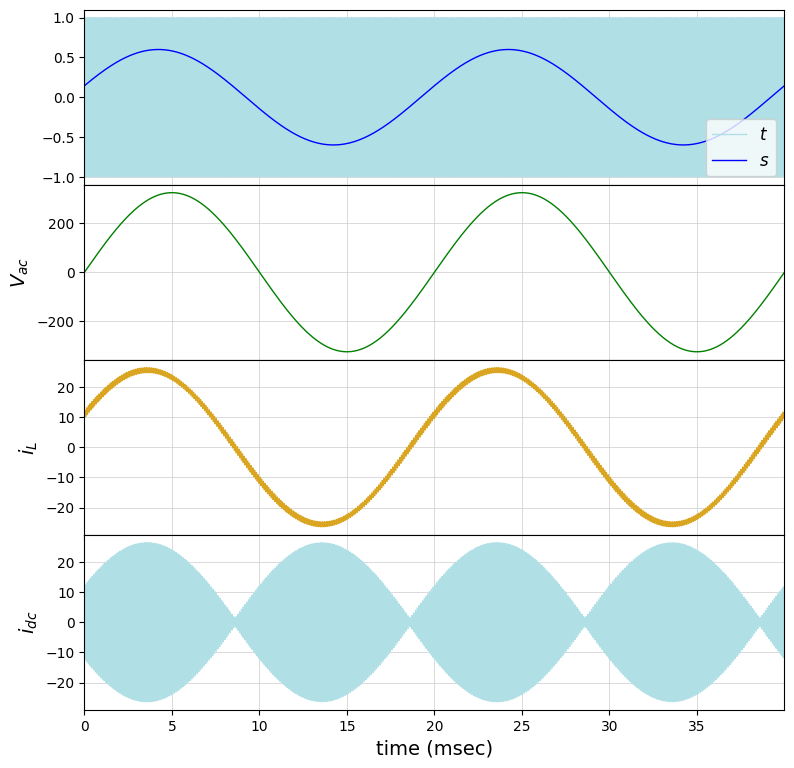

```python
import numpy as np
import matplotlib.pyplot as plt
import gseim_calc as calc
from setsize import set_size

slv = calc.slv("VSC_bi_5.in")

i_slv = 0
i_out = 0
filename = slv.l_filename_all[i_slv][i_out]
print('filename:', filename)
u = np.loadtxt(filename)
t = u[:, 0]
t0 = t[0]
t = t - t0

v_ac = slv.get_array_double(i_slv,i_out,"v_ac",u)
IL   = slv.get_array_double(i_slv,i_out,"IL",u)
Idc  = slv.get_array_double(i_slv,i_out,"Idc",u)
s1   = slv.get_array_double(i_slv,i_out,"s",u)
t1   = slv.get_array_double(i_slv,i_out,"t",u)

# since we have stored two cycles, we need to divide the last time point
# by 2 to get the period:

T = t[-1]/2

color1='green'
color2='crimson'
color3='goldenrod'
color4='blue'
color5='powderblue'

fig, ax = plt.subplots(4, sharex=False)
plt.subplots_adjust(wspace=0, hspace=0.0)

set_size(7, 7, ax[0])

for i in range(4):
    ax[i].set_xlim(left=0, right=2.0*T*1e3)
    ax[i].grid(color='#CCCCCC', linestyle='solid', linewidth=0.5)

for i in range(3):
    ax[i].tick_params(labelbottom=False)

ax[0].plot(t*1e3, t1  , color=color5, linewidth=1.0, label="$t$")
ax[0].plot(t*1e3, s1  , color=color4, linewidth=1.0, label="$s$")
ax[1].plot(t*1e3, v_ac, color=color1, linewidth=1.0, label="$v_{ac}$")
ax[2].plot(t*1e3, IL  , color=color3, linewidth=1.0, label="$i_L$")
ax[3].plot(t*1e3,-Idc , color=color5, linewidth=1.0, label="$i_{dc}$")

ax[1].set_ylabel(r'$V_{ac}$', fontsize=14)
ax[2].set_ylabel(r'$i_L$'   , fontsize=14)
ax[3].set_ylabel(r'$i_{dc}$', fontsize=14)

ax[3].set_xlabel('time (msec)', fontsize=14)

ax[0].legend(loc = 'lower right',frameon = True, fontsize = 10, title = None,
   markerfirst = True, markerscale = 1.0, labelspacing = 0.5, columnspacing = 2.0,
   prop = {'size' : 12},)

#plt.tight_layout()
plt.show()
```

```
filename: VSI_bi_5.dat
i_dc 100-Hz component: amplitude:   7.6565E+00
```

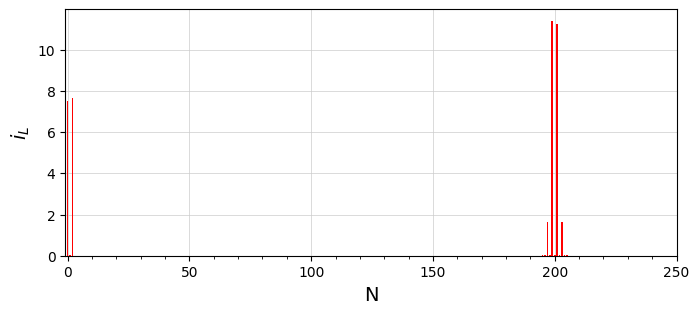

```python
import numpy as np
import matplotlib.pyplot as plt
from matplotlib.ticker import (MultipleLocator, AutoMinorLocator)
import gseim_calc as calc
from setsize import set_size

slv = calc.slv("VSC_bi_5.in")

i_slv = 0
i_out = 0
filename = slv.l_filename_all[i_slv][i_out]
print('filename:', filename)
u = np.loadtxt(filename)
t = u[:, 0]
t0 = t[0]
t = t - t0

Idc = slv.get_array_double(i_slv,i_out,"Idc",u)

# since we have stored two cycles, we need to divide the last time point
# by 2 to get the period:

T = t[-1]/2

# compute Fourier coeffs:

t_start = T
t_end = 2.0*T

n_fourier = 250

coeff_Idc, thd_Idc = calc.fourier_coeff_1C(t, Idc,
    t_start, t_end, 1.0e-8, n_fourier)

print("i_dc 100-Hz component: amplitude: ", "%11.4E"%(coeff_Idc[2]))

x = np.linspace(0, n_fourier, n_fourier+1)

y_Idc = np.array(coeff_Idc)

fig, ax = plt.subplots()
plt.subplots_adjust(wspace=0, hspace=0.0)

set_size(5.5, 2.5, ax)

plt.grid(color='#CCCCCC', linestyle='solid', linewidth=0.5)

delta = 50.0
x_major_ticks = np.arange(0.0, (float(n_fourier+1)), delta)
x_minor_ticks = np.arange(0.0, (float(n_fourier+1)), delta/5)

ax.set_xlim(left=-1.0, right=float(n_fourier))
ax.set_xticks(x_major_ticks)
ax.set_xticks(x_minor_ticks, minor=True)
ax.grid(visible=True, which='major', axis='x', color='#CCCCCC', linestyle='-', zorder=0)
ax.set_ylabel('$i_L$',fontsize=14)
ax.set_xlabel('N', fontsize=14)

bars1 = ax.bar(x, y_Idc, width=0.7, color='red',  label="$i_{dc}$", zorder=3)

plt.tight_layout()
plt.show()
```

```
filename: VSI_bi_5.dat
phasors in polar form:
v_ac: magnitude:  325.27, angle:   -0.00 deg
v_BD: magnitude:  299.95, angle:   14.00 deg
VL  : magnitude:   80.22, angle:  115.27 deg
```

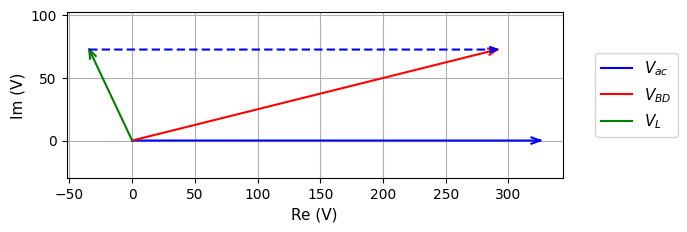

```python
import numpy as np
import gseim_calc as calc
import os
import dos_unix
import cmath
import matplotlib.pyplot as plt
from matplotlib.ticker import (MultipleLocator, AutoMinorLocator)
from setsize import set_size

slv = calc.slv("VSC_bi_5.in")

i_slv = 0
i_out = 0
filename = slv.l_filename_all[i_slv][i_out]
print('filename:', filename)
u = np.loadtxt(filename)
t = u[:, 0]
t0 = t[0]
t = t - t0

v_ac = slv.get_array_double(i_slv,i_out,"v_ac",u)
v_BD = slv.get_array_double(i_slv,i_out,"v_BD",u)
VL   = slv.get_array_double(i_slv,i_out,"VL",  u)

T = t[-1]/2

coeff_v_ac, thd_v_ac, coeff_a_v_ac, coeff_b_v_ac = calc.fourier_coeff_2A(t, v_ac, 0.0, T, 1.0e-8*T, 1)
coeff_v_BD, thd_v_BD, coeff_a_v_BD, coeff_b_v_BD = calc.fourier_coeff_2A(t, v_BD, 0.0, T, 1.0e-8*T, 1)
coeff_VL  , thd_VL  , coeff_a_VL  , coeff_b_VL   = calc.fourier_coeff_2A(t, VL  , 0.0, T, 1.0e-8*T, 1)

k_fourier = 1

A_v_ac, theta_rad_v_ac, theta_deg_v_ac = calc.get_mag_angle_1(k_fourier, coeff_a_v_ac, coeff_b_v_ac)
A_v_BD, theta_rad_v_BD, theta_deg_v_BD = calc.get_mag_angle_1(k_fourier, coeff_a_v_BD, coeff_b_v_BD)
A_VL  , theta_rad_VL  , theta_deg_VL   = calc.get_mag_angle_1(k_fourier, coeff_a_VL  , coeff_b_VL  )

z_v_ac = cmath.rect(A_v_ac, (theta_rad_v_ac + np.pi/2))
z_v_BD = cmath.rect(A_v_BD, (theta_rad_v_BD + np.pi/2))
z_VL   = cmath.rect(A_VL  , (theta_rad_VL   + np.pi/2))

print('phasors in polar form:')

s_format = "%7.2f"

calc.print_complex_polar('v_ac', z_v_ac, s_format)
calc.print_complex_polar('v_BD', z_v_BD, s_format)
calc.print_complex_polar('VL  ', z_VL  , s_format)

l_colors = ["blue", "red", "green", "grey", "dodgerblue", "tomato"]

l1 = []
l1_labels = []

color_v_ac = calc.phasor_append_1a(l1, l1_labels, z_v_ac, "$V_{ac}$", l_colors)
color_v_BD = calc.phasor_append_1a(l1, l1_labels, z_v_BD, "$V_{BD}$", l_colors)
color_VL   = calc.phasor_append_1a(l1, l1_labels, z_VL  , "$V_L$"   , l_colors)

theta_deg = 20.0
length_arrow = calc.phasor_3(l1, 0.02)
l1_arrow = calc.phasor_2(l1, theta_deg, length_arrow, 0.2)

l2 = []
l2_colors = []

calc.phasor_append_2(l2, l2_colors, z_VL, (z_VL + z_v_ac), color_v_ac)

l2_arrow = calc.phasor_2(l2, theta_deg, length_arrow, 0.2)

fig, ax = plt.subplots()
ax.set_aspect('equal', adjustable='box')
ax.grid()

for i, l_dummy in enumerate(l1_arrow):
    for k, t in enumerate(l_dummy):
        if (k == 0):
            ax.plot(t[0],t[1], color=l_colors[i], label=l1_labels[i])
        else:
            ax.plot(t[0],t[1], color=l_colors[i])

for i, l_dummy in enumerate(l2_arrow):
    for k, t in enumerate(l_dummy):
        ax.plot(t[0],t[1], color=l2_colors[i], linestyle='--', dashes=(4, 2))

calc.revise_axis_limits_1(ax, 3.0)
ax.legend(loc='center left', fontsize=11, bbox_to_anchor=(1.05, 0.5))

plt.xlabel('Re (V)', fontsize=11)
plt.ylabel('Im (V)', fontsize=11)
plt.show()
```

This notebook was contributed by **Prof. Nakul Narayanan K**, Govt. Engineering College, Thrissur. He may be contacted at nakul@gectcr.ac.in.